# Risk Factor Analysis

## Outcome Variable

**Outcome Variable:** pers_wasted624

## Predictor Variables

**Intervention Variable:** ever_wasted06

**Adjustment Set:**

- sex
- arm
- enstunt
- month
- brthmon
- vagbrth
- single
- W_gagebrth
- W_birthwt
- W_birthlen
- W_mage
- W_mhtcm
- W_meducyrs
- W_feducyrs
- W_parity
- delta_month
- delta_brthmon
- delta_vagbrth
- delta_single
- delta_W_gagebrth
- delta_W_birthwt
- delta_W_birthlen
- delta_W_mage
- delta_W_mhtcm
- delta_W_meducyrs
- delta_W_feducyrs
- delta_W_parity

## Stratifying Variables

The analysis was stratified on these variable(s):

- studyid
- country

## Data Summary

| studyid | country | ever_wasted06 | pers_wasted624 | n_cell | n |
| --- | --- | --- | --- | --- | --- |
| ki0047075b-MAL-ED | BANGLADESH | 0 | 0 | 180 | 239 |
| ki0047075b-MAL-ED | BANGLADESH | 0 | 1 | 5 | 239 |
| ki0047075b-MAL-ED | BANGLADESH | 1 | 0 | 41 | 239 |
| ki0047075b-MAL-ED | BANGLADESH | 1 | 1 | 13 | 239 |
| ki0047075b-MAL-ED | BRAZIL | 0 | 0 | 187 | 202 |
| ki0047075b-MAL-ED | BRAZIL | 0 | 1 | 1 | 202 |
| ki0047075b-MAL-ED | BRAZIL | 1 | 0 | 13 | 202 |
| ki0047075b-MAL-ED | BRAZIL | 1 | 1 | 1 | 202 |
| ki0047075b-MAL-ED | INDIA | 0 | 0 | 154 | 234 |
| ki0047075b-MAL-ED | INDIA | 0 | 1 | 6 | 234 |
| ki0047075b-MAL-ED | INDIA | 1 | 0 | 52 | 234 |
| ki0047075b-MAL-ED | INDIA | 1 | 1 | 22 | 234 |
| ki0047075b-MAL-ED | NEPAL | 0 | 0 | 194 | 234 |
| ki0047075b-MAL-ED | NEPAL | 0 | 1 | 0 | 234 |
| ki0047075b-MAL-ED | NEPAL | 1 | 0 | 38 | 234 |
| ki0047075b-MAL-ED | NEPAL | 1 | 1 | 2 | 234 |
| ki0047075b-MAL-ED | PERU | 0 | 0 | 252 | 264 |
| ki0047075b-MAL-ED | PERU | 0 | 1 | 2 | 264 |
| ki0047075b-MAL-ED | PERU | 1 | 0 | 10 | 264 |
| ki0047075b-MAL-ED | PERU | 1 | 1 | 0 | 264 |
| ki0047075b-MAL-ED | SOUTH AFRICA | 0 | 0 | 232 | 258 |
| ki0047075b-MAL-ED | SOUTH AFRICA | 0 | 1 | 0 | 258 |
| ki0047075b-MAL-ED | SOUTH AFRICA | 1 | 0 | 24 | 258 |
| ki0047075b-MAL-ED | SOUTH AFRICA | 1 | 1 | 2 | 258 |
| ki0047075b-MAL-ED | TANZANIA, UNITED REPUBLIC OF | 0 | 0 | 233 | 244 |
| ki0047075b-MAL-ED | TANZANIA, UNITED REPUBLIC OF | 0 | 1 | 0 | 244 |
| ki0047075b-MAL-ED | TANZANIA, UNITED REPUBLIC OF | 1 | 0 | 11 | 244 |
| ki0047075b-MAL-ED | TANZANIA, UNITED REPUBLIC OF | 1 | 1 | 0 | 244 |
| ki1000108-CMC-V-BCS-2002 | INDIA | 0 | 0 | 174 | 368 |
| ki1000108-CMC-V-BCS-2002 | INDIA | 0 | 1 | 3 | 368 |

[output cut: 118 more lines]

The following strata were considered:

- studyid: ki0047075b-MAL-ED, country: BANGLADESH
- studyid: ki0047075b-MAL-ED, country: BRAZIL
- studyid: ki0047075b-MAL-ED, country: INDIA
- studyid: ki0047075b-MAL-ED, country: NEPAL
- studyid: ki0047075b-MAL-ED, country: PERU
- studyid: ki0047075b-MAL-ED, country: SOUTH AFRICA
- studyid: ki0047075b-MAL-ED, country: TANZANIA, UNITED REPUBLIC OF
- studyid: ki1000108-CMC-V-BCS-2002, country: INDIA
- studyid: ki1000108-IRC, country: INDIA
- studyid: ki1000109-EE, country: PAKISTAN
- studyid: ki1000109-ResPak, country: PAKISTAN
- studyid: ki1000304-VITAMIN-A, country: INDIA
- studyid: ki1000304b-SAS-CompFeed, country: INDIA
- studyid: ki1000304b-SAS-FoodSuppl, country: INDIA
- studyid: ki1017093-NIH-Birth, country: BANGLADESH
- studyid: ki1017093b-PROVIDE, country: BANGLADESH
- studyid: ki1017093c-NIH-Crypto, country: BANGLADESH
- studyid: ki1066203-TanzaniaChild2, country: TANZANIA, UNITED REPUBLIC OF
- studyid: ki1101329-Keneba, country: GAMBIA
- studyid: ki1112895-Burkina Faso Zn, country: BURKINA FASO
- studyid: ki1112895-Guatemala BSC, country: GUATEMALA
- studyid: ki1113344-GMS-Nepal, country: NEPAL
- studyid: ki1114097-CMIN, country: BANGLADESH
- studyid: ki1114097-CMIN, country: BRAZIL
- studyid: ki1114097-CMIN, country: GUINEA-BISSAU
- studyid: ki1114097-CMIN, country: PERU
- studyid: ki1114097-CONTENT, country: PERU
- studyid: ki1119695-PROBIT, country: BELARUS
- studyid: ki1126311-ZVITAMBO, country: ZIMBABWE
- studyid: ki1135781-COHORTS, country: GUATEMALA
- studyid: ki1135781-COHORTS, country: INDIA
- studyid: ki1135781-COHORTS, country: PHILIPPINES
- studyid: ki1148112-iLiNS-DOSE, country: MALAWI
- studyid: ki1148112-iLiNS-DYAD-M, country: MALAWI
- studyid: ki1148112-LCNI-5, country: MALAWI
- studyid: kiGH5241-JiVitA-3, country: BANGLADESH
- studyid: kiGH5241-JiVitA-4, country: BANGLADESH

### Dropped Strata

Some strata were dropped due to rare outcomes:

- studyid: ki0047075b-MAL-ED, country: BRAZIL
- studyid: ki0047075b-MAL-ED, country: NEPAL
- studyid: ki0047075b-MAL-ED, country: PERU
- studyid: ki0047075b-MAL-ED, country: SOUTH AFRICA
- studyid: ki0047075b-MAL-ED, country: TANZANIA, UNITED REPUBLIC OF
- studyid: ki1000108-CMC-V-BCS-2002, country: INDIA
- studyid: ki1112895-Burkina Faso Zn, country: BURKINA FASO
- studyid: ki1112895-Guatemala BSC, country: GUATEMALA
- studyid: ki1114097-CMIN, country: BRAZIL
- studyid: ki1114097-CMIN, country: PERU
- studyid: ki1114097-CONTENT, country: PERU
- studyid: ki1148112-iLiNS-DOSE, country: MALAWI
- studyid: ki1148112-iLiNS-DYAD-M, country: MALAWI
- studyid: ki1148112-LCNI-5, country: MALAWI

## Methods Detail

We’re interested in the causal parameters $E[Y_a]$ for all values of $a \in \mathcal{A}$. These parameters represent the mean outcome if, possibly contrary to fact, we intervened to set all units to have $A=a$. Under the randomization and positivity assumptions, these are identified by the statistical parameters $\psi_a=E_W[E_{Y|A,W}(Y|A=a,W)]$. In addition, we’re interested in the mean of $Y$, $E[Y]$ under no intervention (the observed mean). We will estimate these parameters by using SuperLearner to fit the relevant likelihood factors – $E_{Y|A,W}(Y|A=a,W)$ and $p(A=a|W)$, and then updating our likelihood fit using a joint TMLE.

For unadjusted analyses ($W=\{\}$), initial likelihoods were estimated using Lrnr_glm to estimate the simple $E(Y|A)$ and Lrnr_mean to estimate $p(A)$. For adjusted analyses, a small library containing Lrnr_glmnet, Lrnr_xgboost, and Lrnr_mean was used.

Having estimated these parameters, we will then use the delta method to estimate relative risks and attributable risks relative to a prespecified baseline level of $A$.

# Results Detail

## Results Plots

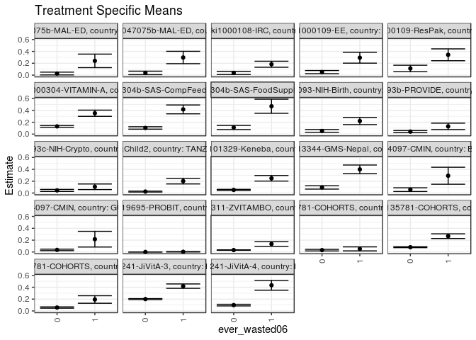

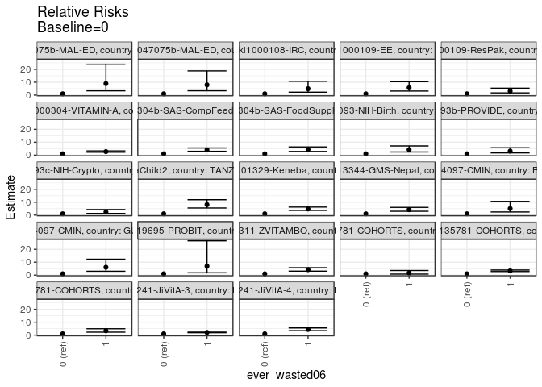

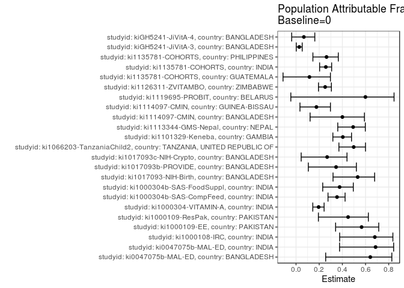

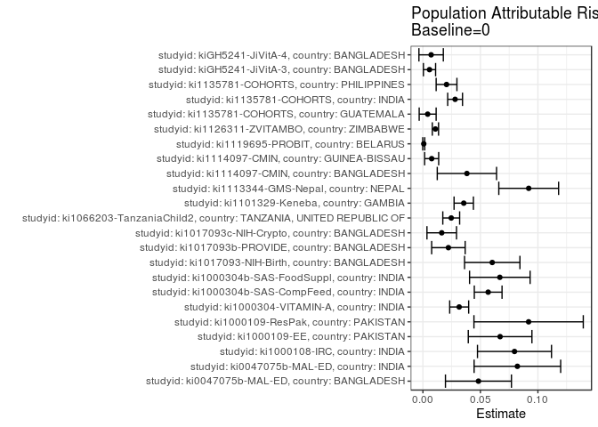

## Results Table

### Parameter: TSM

| studyid | country | intervention_level | baseline_level | estimate | ci_lower | ci_upper |
| --- | --- | --- | --- | --- | --- | --- |
| ki0047075b-MAL-ED | BANGLADESH | 0 | NA | 0.0270270 | 0.0036105 | 0.0504435 |
| ki0047075b-MAL-ED | BANGLADESH | 1 | NA | 0.2407407 | 0.1264709 | 0.3550106 |
| ki0047075b-MAL-ED | INDIA | 0 | NA | 0.0375000 | 0.0079992 | 0.0670008 |
| ki0047075b-MAL-ED | INDIA | 1 | NA | 0.2972973 | 0.1929350 | 0.4016596 |
| ki1000108-IRC | INDIA | 0 | NA | 0.0374332 | 0.0101935 | 0.0646728 |
| ki1000108-IRC | INDIA | 1 | NA | 0.1838565 | 0.1329529 | 0.2347601 |
| ki1000109-EE | PAKISTAN | 0 | NA | 0.0514752 | 0.0250735 | 0.0778769 |
| ki1000109-EE | PAKISTAN | 1 | NA | 0.2939030 | 0.2022099 | 0.3855961 |
| ki1000109-ResPak | PAKISTAN | 0 | NA | 0.1126262 | 0.0585171 | 0.1667353 |
| ki1000109-ResPak | PAKISTAN | 1 | NA | 0.3429091 | 0.2429537 | 0.4428646 |
| ki1000304-VITAMIN-A | INDIA | 0 | NA | 0.1302055 | 0.1153666 | 0.1450444 |
| ki1000304-VITAMIN-A | INDIA | 1 | NA | 0.3517516 | 0.2993225 | 0.4041808 |
| ki1000304b-SAS-CompFeed | INDIA | 0 | NA | 0.1036082 | 0.0833916 | 0.1238248 |
| ki1000304b-SAS-CompFeed | INDIA | 1 | NA | 0.4163459 | 0.3416636 | 0.4910282 |
| ki1000304b-SAS-FoodSuppl | INDIA | 0 | NA | 0.1109472 | 0.0763132 | 0.1455813 |
| ki1000304b-SAS-FoodSuppl | INDIA | 1 | NA | 0.4695739 | 0.3502143 | 0.5889335 |
| ki1017093-NIH-Birth | BANGLADESH | 0 | NA | 0.0529958 | 0.0287971 | 0.0771945 |
| ki1017093-NIH-Birth | BANGLADESH | 1 | NA | 0.2204726 | 0.1598380 | 0.2811072 |
| ki1017093b-PROVIDE | BANGLADESH | 0 | NA | 0.0419756 | 0.0234745 | 0.0604767 |
| ki1017093b-PROVIDE | BANGLADESH | 1 | NA | 0.1302954 | 0.0761734 | 0.1844175 |
| ki1017093c-NIH-Crypto | BANGLADESH | 0 | NA | 0.0445828 | 0.0272053 | 0.0619603 |
| ki1017093c-NIH-Crypto | BANGLADESH | 1 | NA | 0.1058723 | 0.0588921 | 0.1528526 |
| ki1066203-TanzaniaChild2 | TANZANIA, UNITED REPUBLIC OF | 0 | NA | 0.0248362 | 0.0173018 | 0.0323706 |
| ki1066203-TanzaniaChild2 | TANZANIA, UNITED REPUBLIC OF | 1 | NA | 0.2013425 | 0.1538565 | 0.2488285 |
| ki1101329-Keneba | GAMBIA | 0 | NA | 0.0524084 | 0.0422469 | 0.0625698 |
| ki1101329-Keneba | GAMBIA | 1 | NA | 0.2489387 | 0.2020018 | 0.2958756 |
| ki1113344-GMS-Nepal | NEPAL | 0 | NA | 0.0946430 | 0.0664594 | 0.1228266 |
| ki1113344-GMS-Nepal | NEPAL | 1 | NA | 0.3990600 | 0.3256266 | 0.4724934 |
| ki1114097-CMIN | BANGLADESH | 0 | NA | 0.0573677 | 0.0257700 | 0.0889654 |
| ki1114097-CMIN | BANGLADESH | 1 | NA | 0.2918464 | 0.1486391 | 0.4350537 |
| ki1114097-CMIN | GUINEA-BISSAU | 0 | NA | 0.0356295 | 0.0231019 | 0.0481570 |
| ki1114097-CMIN | GUINEA-BISSAU | 1 | NA | 0.2162162 | 0.0834961 | 0.3489363 |
| ki1119695-PROBIT | BELARUS | 0 | NA | 0.0004875 | 0.0000008 | 0.0009742 |
| ki1119695-PROBIT | BELARUS | 1 | NA | 0.0033800 | 0.0000091 | 0.0067509 |
| ki1126311-ZVITAMBO | ZIMBABWE | 0 | NA | 0.0323481 | 0.0284972 | 0.0361989 |
| ki1126311-ZVITAMBO | ZIMBABWE | 1 | NA | 0.1358160 | 0.0962149 | 0.1754170 |
| ki1135781-COHORTS | GUATEMALA | 0 | NA | 0.0315513 | 0.0186078 | 0.0444947 |
| ki1135781-COHORTS | GUATEMALA | 1 | NA | 0.0526900 | 0.0188240 | 0.0865561 |
| ki1135781-COHORTS | INDIA | 0 | NA | 0.0807850 | 0.0736804 | 0.0878895 |
| ki1135781-COHORTS | INDIA | 1 | NA | 0.2670764 | 0.2276397 | 0.3065131 |
| ki1135781-COHORTS | PHILIPPINES | 0 | NA | 0.0574740 | 0.0464549 | 0.0684931 |
| ki1135781-COHORTS | PHILIPPINES | 1 | NA | 0.1932955 | 0.1298803 | 0.2567107 |
| kiGH5241-JiVitA-3 | BANGLADESH | 0 | NA | 0.1999311 | 0.1914408 | 0.2084214 |
| kiGH5241-JiVitA-3 | BANGLADESH | 1 | NA | 0.4182166 | 0.3810014 | 0.4554318 |
| kiGH5241-JiVitA-4 | BANGLADESH | 0 | NA | 0.0987337 | 0.0845469 | 0.1129205 |
| kiGH5241-JiVitA-4 | BANGLADESH | 1 | NA | 0.4330903 | 0.3504519 | 0.5157286 |

### Parameter: E(Y)

| studyid | country | intervention_level | baseline_level | estimate | ci_lower | ci_upper |
| --- | --- | --- | --- | --- | --- | --- |
| ki0047075b-MAL-ED | BANGLADESH | NA | NA | 0.0753138 | 0.0417869 | 0.1088408 |
| ki0047075b-MAL-ED | INDIA | NA | NA | 0.1196581 | 0.0779840 | 0.1613323 |
| ki1000108-IRC | INDIA | NA | NA | 0.1170732 | 0.0859146 | 0.1482317 |
| ki1000109-EE | PAKISTAN | NA | NA | 0.1185984 | 0.0856546 | 0.1515422 |
| ki1000109-ResPak | PAKISTAN | NA | NA | 0.2045455 | 0.1511224 | 0.2579685 |
| ki1000304-VITAMIN-A | INDIA | NA | NA | 0.1617391 | 0.1466878 | 0.1767905 |
| ki1000304b-SAS-CompFeed | INDIA | NA | NA | 0.1603563 | 0.1395035 | 0.1812092 |
| ki1000304b-SAS-FoodSuppl | INDIA | NA | NA | 0.1778351 | 0.1397389 | 0.2159312 |
| ki1017093-NIH-Birth | BANGLADESH | NA | NA | 0.1132813 | 0.0858017 | 0.1407608 |
| ki1017093b-PROVIDE | BANGLADESH | NA | NA | 0.0641447 | 0.0446535 | 0.0836359 |
| ki1017093c-NIH-Crypto | BANGLADESH | NA | NA | 0.0609418 | 0.0434802 | 0.0784034 |
| ki1066203-TanzaniaChild2 | TANZANIA, UNITED REPUBLIC OF | NA | NA | 0.0494534 | 0.0397554 | 0.0591514 |
| ki1101329-Keneba | GAMBIA | NA | NA | 0.0879121 | 0.0760335 | 0.0997907 |
| ki1113344-GMS-Nepal | NEPAL | NA | NA | 0.1866438 | 0.1550166 | 0.2182711 |
| ki1114097-CMIN | BANGLADESH | NA | NA | 0.0956175 | 0.0591654 | 0.1320697 |
| ki1114097-CMIN | GUINEA-BISSAU | NA | NA | 0.0432309 | 0.0297785 | 0.0566834 |
| ki1119695-PROBIT | BELARUS | NA | NA | 0.0012159 | 0.0002433 | 0.0021885 |
| ki1126311-ZVITAMBO | ZIMBABWE | NA | NA | 0.0432128 | 0.0388939 | 0.0475316 |
| ki1135781-COHORTS | GUATEMALA | NA | NA | 0.0356745 | 0.0235298 | 0.0478191 |
| ki1135781-COHORTS | INDIA | NA | NA | 0.1087695 | 0.1008135 | 0.1167256 |
| ki1135781-COHORTS | PHILIPPINES | NA | NA | 0.0780116 | 0.0679971 | 0.0880261 |
| kiGH5241-JiVitA-3 | BANGLADESH | NA | NA | 0.2056528 | 0.1980793 | 0.2132263 |
| kiGH5241-JiVitA-4 | BANGLADESH | NA | NA | 0.1058706 | 0.0951082 | 0.1166330 |

### Parameter: RR

| studyid | country | intervention_level | baseline_level | estimate | ci_lower | ci_upper |
| --- | --- | --- | --- | --- | --- | --- |
| ki0047075b-MAL-ED | BANGLADESH | 0 | 0 | 1.000000 | 1.0000000 | 1.000000 |
| ki0047075b-MAL-ED | BANGLADESH | 1 | 0 | 8.907407 | 3.3167043 | 23.921912 |
| ki0047075b-MAL-ED | INDIA | 0 | 0 | 1.000000 | 1.0000000 | 1.000000 |
| ki0047075b-MAL-ED | INDIA | 1 | 0 | 7.927928 | 3.3499192 | 18.762256 |
| ki1000108-IRC | INDIA | 0 | 0 | 1.000000 | 1.0000000 | 1.000000 |
| ki1000108-IRC | INDIA | 1 | 0 | 4.911595 | 2.2547088 | 10.699283 |
| ki1000109-EE | PAKISTAN | 0 | 0 | 1.000000 | 1.0000000 | 1.000000 |
| ki1000109-EE | PAKISTAN | 1 | 0 | 5.709605 | 3.1323197 | 10.407490 |
| ki1000109-ResPak | PAKISTAN | 0 | 0 | 1.000000 | 1.0000000 | 1.000000 |
| ki1000109-ResPak | PAKISTAN | 1 | 0 | 3.044666 | 1.7371075 | 5.336452 |
| ki1000304-VITAMIN-A | INDIA | 0 | 0 | 1.000000 | 1.0000000 | 1.000000 |
| ki1000304-VITAMIN-A | INDIA | 1 | 0 | 2.701512 | 2.2405318 | 3.257336 |
| ki1000304b-SAS-CompFeed | INDIA | 0 | 0 | 1.000000 | 1.0000000 | 1.000000 |
| ki1000304b-SAS-CompFeed | INDIA | 1 | 0 | 4.018466 | 2.9245363 | 5.521583 |
| ki1000304b-SAS-FoodSuppl | INDIA | 0 | 0 | 1.000000 | 1.0000000 | 1.000000 |
| ki1000304b-SAS-FoodSuppl | INDIA | 1 | 0 | 4.232407 | 2.8277357 | 6.334847 |
| ki1017093-NIH-Birth | BANGLADESH | 0 | 0 | 1.000000 | 1.0000000 | 1.000000 |
| ki1017093-NIH-Birth | BANGLADESH | 1 | 0 | 4.160191 | 2.4383838 | 7.097811 |
| ki1017093b-PROVIDE | BANGLADESH | 0 | 0 | 1.000000 | 1.0000000 | 1.000000 |
| ki1017093b-PROVIDE | BANGLADESH | 1 | 0 | 3.104076 | 1.6946471 | 5.685719 |
| ki1017093c-NIH-Crypto | BANGLADESH | 0 | 0 | 1.000000 | 1.0000000 | 1.000000 |
| ki1017093c-NIH-Crypto | BANGLADESH | 1 | 0 | 2.374737 | 1.3152650 | 4.287635 |
| ki1066203-TanzaniaChild2 | TANZANIA, UNITED REPUBLIC OF | 0 | 0 | 1.000000 | 1.0000000 | 1.000000 |
| ki1066203-TanzaniaChild2 | TANZANIA, UNITED REPUBLIC OF | 1 | 0 | 8.106825 | 5.5186706 | 11.908775 |
| ki1101329-Keneba | GAMBIA | 0 | 0 | 1.000000 | 1.0000000 | 1.000000 |
| ki1101329-Keneba | GAMBIA | 1 | 0 | 4.749979 | 3.6288301 | 6.217513 |
| ki1113344-GMS-Nepal | NEPAL | 0 | 0 | 1.000000 | 1.0000000 | 1.000000 |
| ki1113344-GMS-Nepal | NEPAL | 1 | 0 | 4.216475 | 2.9736920 | 5.978649 |
| ki1114097-CMIN | BANGLADESH | 0 | 0 | 1.000000 | 1.0000000 | 1.000000 |
| ki1114097-CMIN | BANGLADESH | 1 | 0 | 5.087293 | 2.4318452 | 10.642353 |
| ki1114097-CMIN | GUINEA-BISSAU | 0 | 0 | 1.000000 | 1.0000000 | 1.000000 |
| ki1114097-CMIN | GUINEA-BISSAU | 1 | 0 | 6.068468 | 2.9912946 | 12.311161 |
| ki1119695-PROBIT | BELARUS | 0 | 0 | 1.000000 | 1.0000000 | 1.000000 |
| ki1119695-PROBIT | BELARUS | 1 | 0 | 6.932963 | 1.8068114 | 26.602654 |
| ki1126311-ZVITAMBO | ZIMBABWE | 0 | 0 | 1.000000 | 1.0000000 | 1.000000 |
| ki1126311-ZVITAMBO | ZIMBABWE | 1 | 0 | 4.198582 | 3.0645313 | 5.752296 |
| ki1135781-COHORTS | GUATEMALA | 0 | 0 | 1.000000 | 1.0000000 | 1.000000 |
| ki1135781-COHORTS | GUATEMALA | 1 | 0 | 1.669982 | 0.7789104 | 3.580439 |
| ki1135781-COHORTS | INDIA | 0 | 0 | 1.000000 | 1.0000000 | 1.000000 |
| ki1135781-COHORTS | INDIA | 1 | 0 | 3.306017 | 2.7856799 | 3.923547 |
| ki1135781-COHORTS | PHILIPPINES | 0 | 0 | 1.000000 | 1.0000000 | 1.000000 |
| ki1135781-COHORTS | PHILIPPINES | 1 | 0 | 3.363182 | 2.3016456 | 4.914307 |
| kiGH5241-JiVitA-3 | BANGLADESH | 0 | 0 | 1.000000 | 1.0000000 | 1.000000 |
| kiGH5241-JiVitA-3 | BANGLADESH | 1 | 0 | 2.091803 | 1.8986385 | 2.304620 |
| kiGH5241-JiVitA-4 | BANGLADESH | 0 | 0 | 1.000000 | 1.0000000 | 1.000000 |
| kiGH5241-JiVitA-4 | BANGLADESH | 1 | 0 | 4.386447 | 3.4539707 | 5.570666 |

### Parameter: PAR

| studyid | country | intervention_level | baseline_level | estimate | ci_lower | ci_upper |
| --- | --- | --- | --- | --- | --- | --- |
| ki0047075b-MAL-ED | BANGLADESH | 0 | NA | 0.0482868 | 0.0195900 | 0.0769836 |
| ki0047075b-MAL-ED | INDIA | 0 | NA | 0.0821581 | 0.0445166 | 0.1197996 |
| ki1000108-IRC | INDIA | 0 | NA | 0.0796400 | 0.0474529 | 0.1118271 |
| ki1000109-EE | PAKISTAN | 0 | NA | 0.0671232 | 0.0394455 | 0.0948009 |
| ki1000109-ResPak | PAKISTAN | 0 | NA | 0.0919193 | 0.0443756 | 0.1394629 |
| ki1000304-VITAMIN-A | INDIA | 0 | NA | 0.0315336 | 0.0232842 | 0.0397831 |
| ki1000304b-SAS-CompFeed | INDIA | 0 | NA | 0.0567482 | 0.0446869 | 0.0688095 |
| ki1000304b-SAS-FoodSuppl | INDIA | 0 | NA | 0.0668878 | 0.0405613 | 0.0932143 |
| ki1017093-NIH-Birth | BANGLADESH | 0 | NA | 0.0602855 | 0.0362041 | 0.0843668 |
| ki1017093b-PROVIDE | BANGLADESH | 0 | NA | 0.0221691 | 0.0075987 | 0.0367396 |
| ki1017093c-NIH-Crypto | BANGLADESH | 0 | NA | 0.0163591 | 0.0035126 | 0.0292055 |
| ki1066203-TanzaniaChild2 | TANZANIA, UNITED REPUBLIC OF | 0 | NA | 0.0246172 | 0.0172907 | 0.0319438 |
| ki1101329-Keneba | GAMBIA | 0 | NA | 0.0355037 | 0.0270917 | 0.0439157 |
| ki1113344-GMS-Nepal | NEPAL | 0 | NA | 0.0920008 | 0.0660009 | 0.1180007 |
| ki1114097-CMIN | BANGLADESH | 0 | NA | 0.0382498 | 0.0124673 | 0.0640323 |
| ki1114097-CMIN | GUINEA-BISSAU | 0 | NA | 0.0076015 | 0.0014989 | 0.0137041 |
| ki1119695-PROBIT | BELARUS | 0 | NA | 0.0007284 | -0.0001416 | 0.0015983 |
| ki1126311-ZVITAMBO | ZIMBABWE | 0 | NA | 0.0108647 | 0.0081400 | 0.0135895 |
| ki1135781-COHORTS | GUATEMALA | 0 | NA | 0.0041232 | -0.0032491 | 0.0114955 |
| ki1135781-COHORTS | INDIA | 0 | NA | 0.0279846 | 0.0215368 | 0.0344324 |
| ki1135781-COHORTS | PHILIPPINES | 0 | NA | 0.0205376 | 0.0115070 | 0.0295682 |
| kiGH5241-JiVitA-3 | BANGLADESH | 0 | NA | 0.0057217 | 0.0004074 | 0.0110360 |
| kiGH5241-JiVitA-4 | BANGLADESH | 0 | NA | 0.0071369 | -0.0034743 | 0.0177481 |

### Parameter: PAF

| studyid | country | intervention_level | baseline_level | estimate | ci_lower | ci_upper |
| --- | --- | --- | --- | --- | --- | --- |
| ki0047075b-MAL-ED | BANGLADESH | 0 | NA | 0.6411411 | 0.2558997 | 0.8269324 |
| ki0047075b-MAL-ED | INDIA | 0 | NA | 0.6866071 | 0.3757083 | 0.8426776 |
| ki1000108-IRC | INDIA | 0 | NA | 0.6802585 | 0.3765411 | 0.8360202 |
| ki1000109-EE | PAKISTAN | 0 | NA | 0.5659705 | 0.3415081 | 0.7139197 |
| ki1000109-ResPak | PAKISTAN | 0 | NA | 0.4493830 | 0.1929696 | 0.6243276 |
| ki1000304-VITAMIN-A | INDIA | 0 | NA | 0.1949660 | 0.1447143 | 0.2422653 |
| ki1000304b-SAS-CompFeed | INDIA | 0 | NA | 0.3538879 | 0.2759583 | 0.4234299 |
| ki1000304b-SAS-FoodSuppl | INDIA | 0 | NA | 0.3761228 | 0.2303112 | 0.4943115 |
| ki1017093-NIH-Birth | BANGLADESH | 0 | NA | 0.5321751 | 0.3193274 | 0.6784649 |
| ki1017093b-PROVIDE | BANGLADESH | 0 | NA | 0.3456112 | 0.1061757 | 0.5209073 |
| ki1017093c-NIH-Crypto | BANGLADESH | 0 | NA | 0.2684374 | 0.0443520 | 0.4399780 |
| ki1066203-TanzaniaChild2 | TANZANIA, UNITED REPUBLIC OF | 0 | NA | 0.4977865 | 0.3699909 | 0.5996591 |
| ki1101329-Keneba | GAMBIA | 0 | NA | 0.4038547 | 0.3178226 | 0.4790370 |
| ki1113344-GMS-Nepal | NEPAL | 0 | NA | 0.4929217 | 0.3601785 | 0.5981248 |
| ki1114097-CMIN | BANGLADESH | 0 | NA | 0.4000293 | 0.1212427 | 0.5903706 |
| ki1114097-CMIN | GUINEA-BISSAU | 0 | NA | 0.1758345 | 0.0338712 | 0.2969377 |
| ki1119695-PROBIT | BELARUS | 0 | NA | 0.5990331 | -0.0451102 | 0.8461650 |
| ki1126311-ZVITAMBO | ZIMBABWE | 0 | NA | 0.2514238 | 0.1936925 | 0.3050216 |
| ki1135781-COHORTS | GUATEMALA | 0 | NA | 0.1155789 | -0.1123887 | 0.2968279 |
| ki1135781-COHORTS | INDIA | 0 | NA | 0.2572833 | 0.2036135 | 0.3073363 |
| ki1135781-COHORTS | PHILIPPINES | 0 | NA | 0.2632635 | 0.1455337 | 0.3647722 |
| kiGH5241-JiVitA-3 | BANGLADESH | 0 | NA | 0.0278221 | 0.0017908 | 0.0531745 |
| kiGH5241-JiVitA-4 | BANGLADESH | 0 | NA | 0.0674117 | -0.0377520 | 0.1619183 |